# Compare GO Terms

### Necessary packages:

```r
library(dplyr)
library(stringr)
```

# GO terms, direct from tools

## eggNOG

```r
eggnog <- read.delim("eggnogmap_results/diamond_annotations.tabular",
                     stringsAsFactors = FALSE,
                     header = FALSE)
# get all unique go terms from all peptides
eggnog_gos <- unlist(str_split(eggnog$V6, ",")) %>% unique()
# take out empty entry
eggnog_gos_clean <- eggnog_gos[str_sub(eggnog_gos, 1, 2) == "GO"]
```

We are going to write the lists to file, for later use in Python. First, I define a function `clean_write()` which writes a list without all the quotes and stuff:

```r
clean_write <- function(object, file){
    write.table(object, file=file, quote = FALSE, row.names = FALSE, col.names = FALSE)
}
```

Write list to file for later use:

```r
eggnog_list_file <- "go_lists/eggnog.tab"
clean_write(eggnog_gos_clean, file=eggnog_list_file)
```

## MetaGOmics

```r
metagomics <- read.delim("metaGOmics_results/go_compare_149_150.txt",
                             stringsAsFactors = FALSE,
                             comment.char = "#")
metagomics_gos <- metagomics$GO.acc %>%  unique()
# takes out "unknownprc", "unknowncmp", "unknownfun"
metagomics_gos_clean <- metagomics_gos[str_sub(metagomics_gos, 1, 2) == "GO"]
clean_write(metagomics_gos_clean, file="go_lists/metagomics.tab")
```

## MEGAN6

These go terms come from querying the eggNOG database with the orthologous group ids, contained in `MEGAN_outputs/737NSvsWS_EGGNOGcount.csv`. The Python function to do this is in `MEGAN_outputs/get_gos_from_ogs.py`.

```r
megan <- read.delim("MEGAN_outputs/go_terms.txt",
                        header = TRUE,
                        stringsAsFactors = FALSE)
megan_go_lists <- megan$gos
megan_gos <- unlist(str_split(megan_go_lists, pattern = ",")) %>% unique()
megan_gos_clean <- megan_gos[str_sub(megan_gos, 1, 2) == "GO" & !is.na(megan_gos)]
clean_write(megan_gos_clean, file="go_lists/megan.tab")
```

## Unipept

For Unipept, the results are divided into BP, MF, and CC files, so I combine the three ontologies for WS and NS.

```r
unipept_results_NS <- paste('unipept_results/',
                               list.files("unipept_results/", pattern = "^737NS.*\\.csv"),
                               sep = "")
unipept_results_WS <- paste('unipept_results/',
                               list.files("unipept_results/", pattern = "^737WS.*\\.csv"),
                               sep = "")
unipeptNS <- lapply(unipept_results_NS, function(i) {
        read.delim(i, sep = ',', as.is = TRUE)}) %>%
    bind_rows() %>%
    select(-X) %>%
    rename(peptides = X.peptides)
unipeptWS <- lapply(unipept_results_WS, function(i) {
    read.delim(i, sep = ',', as.is = TRUE)}) %>%
    bind_rows() %>%
    select(-X) %>%
    rename(peptides = X.peptides)

unipept_all <- inner_join(unipeptNS, unipeptWS, by = c("GO.term", "Name")) %>%
    rename(countNS = peptides.x, countWS = peptides.y) %>%
    mutate(log2ratio = log(countWS/countNS))

unipept_gos <- unipept_all$GO.term %>% unique()
unipept_gos_clean <- unipept_gos[str_sub(unipept_gos, 1, 2) == "GO"]
clean_write(unipept_gos_clean, file="go_lists/unipept.tab")
```

## MetaProteomeAnalyzer

Here, we get the Uniprot IDs from all of the files, then upload them to the UniProt “Retrieve/ID Mapping” service (https://www.uniprot.org/uploadlists/).

```r
# get all uniprot ids
ns_files <- list.files('mpa_results/NS', pattern = "_proteins.csv", full.names = TRUE)
protNS <- bind_rows(lapply(ns_files, function(i) read.delim(i, stringsAsFactors = FALSE))) %>%
    select("prot" = Protein.Accession) %>% unique()

ws_files <- list.files('mpa_results/WS', pattern = "_proteins.csv", full.names = TRUE)
protWS <- bind_rows(lapply(ws_files, function(i) read.delim(i, stringsAsFactors = FALSE))) %>%
    select("prot" = Protein.Accession) %>% unique()

protAll <- rbind(protNS, protWS) %>% unique()

# write for use on uniprot
clean_write(protAll, file="mpa_results/all_proteins.tab")

# these are the uniprot results from the above file
mpa_uniprot <- read.delim('mpa_results/uniprot_protein_results.tab', stringsAsFactors = FALSE)
mpa_gos <- str_trim(unlist(str_split(mpa_uniprot$Gene.ontology.IDs, ";")))
mpa_gos_clean <- mpa_gos[str_sub(mpa_gos, 1, 2) == "GO"] %>% unique()

clean_write(mpa_gos_clean, file="go_lists/mpa.tab")
```

```r
gos <- list('megan' = megan_gos_clean,
            'metagomics' = metagomics_gos_clean,
            'unipept' = unipept_gos_clean,
            'eggnog' = eggnog_gos_clean,
            'mpa' = mpa_gos_clean)
```

# GO terms: all parents

Download the current GO ontology:

```bash
wget http://purl.obolibrary.org/obo/go/go-basic.obo -O GO_files/go-basic.obo
wget http://www.geneontology.org/ontology/subsets/goslim_generic.obo -O GO_files/go-slim.obo
```

Run python to get the list of all ancestors:

```python
from goatools import obo_parser
from goatools import mapslim
import sys
go = obo_parser.GODag('GO_files/go-basic.obo')
```

```
## load obo file GO_files/go-basic.obo
## GO_files/go-basic.obo: fmt(1.2) rel(2018-05-28) 47,248 GO Terms
```

```python
goslim = obo_parser.GODag('GO_files/go-slim.obo')
```

```
## load obo file GO_files/go-slim.obo
## GO_files/go-slim.obo: fmt(1.2) rel(None) 232 GO Terms
```

```python
def set_of_all_ancestors(terms):
    all_ancestors = set(terms)
    for i in set(terms):
        if i in go.keys():
            all_ancestors.update(go[i].get_all_parents())
    return all_ancestors
def get_all_ancestors(infile, outfile):
    f = open(infile, 'r')
    gos = [x.strip() for x in f.readlines()]
    f.close()

    gos_with_ancestors = set_of_all_ancestors(gos)

    with open(outfile, 'w') as outf:
        for x in gos_with_ancestors:
            outf.write(x + '\n')
def slim_down(infile, outfile):
    f = open(infile, 'r')
    gos = [x.strip() for x in f.readlines()]
    f.close()

    slims = set()
    for i in gos:
        if i in go.keys():
            slims.update(mapslim.mapslim(i, go, goslim)[1])
        else:
            print(i + " not found")

    with open(outfile, 'w') as outf:
        for x in slims:
            outf.write(x + '\n')

for i in ['eggnog', 'megan', 'metagomics', 'unipept', 'mpa']:
    infile = 'go_lists/' + i + '.tab'
    outfile = 'go_lists/' + i + '_parents.tab'
    outslim = 'go_lists/' + i + '_slim.tab'
    get_all_ancestors(infile, outfile)
    print i
    slim_down(infile, outslim)
```

```
## eggnog
## GO:0070271 not found
## GO:0006184 not found
## GO:0006200 not found
## GO:0004871 not found
## GO:0048610 not found
## GO:0042990 not found
## GO:0042992 not found
## GO:0016265 not found
## GO:0003001 not found
## GO:0004716 not found
## GO:0005057 not found
## GO:0033124 not found
## GO:0043581 not found
## GO:0003840 not found
## GO:0007068 not found
## GO:0007070 not found
## GO:0045896 not found
## GO:0046021 not found
## GO:0030969 not found
## GO:0007109 not found
## megan
## GO:0006200 not found
## GO:0070271 not found
## GO:0016265 not found
## metagomics
## GO:0016265 not found
## GO:0004871 not found
## GO:0005057 not found
## unipept
## GO:0004871 not found
## mpa
```

Read ancestors into R.

```r
methods <- c("megan", "metagomics", "unipept", "eggnog", 'mpa')
gos_ancestors <- lapply(methods,
    function(f) {
        "go" = read.delim(paste("go_lists/", f, '_parents.tab', sep = ""),
                              header = FALSE,
                              stringsAsFactors=FALSE)$V1
    }
)
names(gos_ancestors) <- methods
```

# Results:

## Number of GO terms in each tool

Without ancestors

```r
sapply(gos, length)
```

```
##      megan metagomics    unipept     eggnog        mpa
##       1450       3941       2036       6155       1100
```

With ancestors

```r
sapply(gos_ancestors, length)
```

```
##      megan metagomics    unipept     eggnog        mpa
##       1588       4025       4061       6597       2310
```

```r
ex <- rep(0, 5)
for (i in 1:5){
    all <- 1:5
    other_ind <- all[-i]
    others <- unique(c(unlist(gos[other_ind])))
    ex[i] <- length(setdiff(gos[[i]], others))
}
names(ex) <- names(gos)
```

## GO terms in GOslim

```r
methods <- c("megan", "metagomics", "unipept", "eggnog", 'mpa')
gos_slims <- lapply(methods,
    function(f) {
        "go" = read.delim(paste("go_lists/", f, '_slim.tab', sep = ""),
                              header = FALSE,
                              stringsAsFactors=FALSE)$V1
    }
)
names(gos_slims) <- methods

exslim <- rep(0, 5)
for (i in 1:5){
    all <- 1:5
    other_ind <- all[-i]
    others <- unique(c(unlist(gos_slims[other_ind])))
    exslim[i] <- length(setdiff(gos_slims[[i]], others))
}
names(exslim) <- methods
```

## Jaccard distance

```r
jaccard <- function(vec1, vec2){
    c1 <- length(vec1)
    c2 <- length(vec2)
    int <- length(intersect(vec1, vec2))
    (int) / (c1 + c2 - int)
}

jacmat <- matrix(0, nrow = 5, ncol = 5)
for (i in 1:5){
    for (j in 1:5){
        jacmat[i, j] <- jaccard(gos[[i]], gos[[j]])
    }
}
dimnames(jacmat) <- list(names(gos), names(gos))
jacmat
```

```
##                megan metagomics   unipept    eggnog       mpa
## megan      1.0000000  0.2744681 0.1527778 0.1899546 0.1318242
## metagomics 0.2744681  1.0000000 0.3733915 0.3788582 0.2649937
## unipept    0.1527778  0.3733915 1.0000000 0.1976897 0.4633691
## eggnog     0.1899546  0.3788582 0.1976897 1.0000000 0.1320019
## mpa        0.1318242  0.2649937 0.4633691 0.1320019 1.0000000
```

```r
jacslim <- matrix(0, nrow = 5, ncol = 5)
for (i in 1:5){
    for (j in 1:5){
        jacslim[i, j] <- jaccard(gos_slims[[i]], gos_slims[[j]])
    }
}
dimnames(jacslim) <- list(names(gos), names(gos))
jacslim
```

```
##                megan metagomics   unipept    eggnog       mpa
## megan      1.0000000  0.5714286 0.5769231 0.5694444 0.5416667
## metagomics 0.5714286  1.0000000 0.8968254 0.8055556 0.8879310
## unipept    0.5769231  0.8968254 1.0000000 0.8541667 0.8373984
## eggnog     0.5694444  0.8055556 0.8541667 1.0000000 0.7152778
## mpa        0.5416667  0.8879310 0.8373984 0.7152778 1.0000000
```

Levelplots

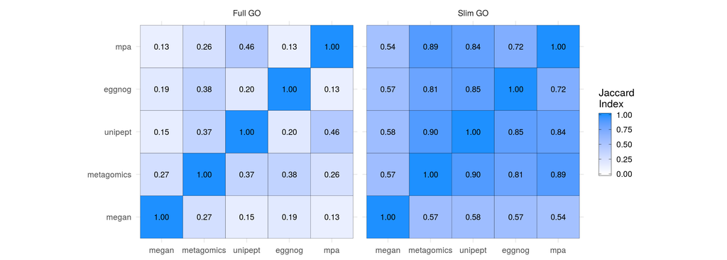

```r
library(reshape2)
library(ggplot2)
jac_melt <- melt(jacmat)
jac_melt$method <- "Full GO"

jac_melt_slim <- melt(jacslim)
jac_melt_slim$method <- "Slim GO"

jac_melt_all <- rbind(jac_melt, jac_melt_slim)
ggplot(jac_melt_all)+
    geom_tile(aes(x = Var1, y = Var2, fill = value), color = "black") +
    geom_text(aes(x = Var1, y = Var2, label = format(value, digits = 2))) +
    scale_fill_gradient(name="Jaccard\nIndex", low = "white", high = "dodgerblue", limits = c(0, 1),
                    guide = guide_colorbar(frame.colour = "black", ticks.colour = "black")) +
    facet_grid(.~method) +
    theme_minimal(base_size = 14) +
    theme(aspect.ratio = 1) +
    labs(x = NULL, y = NULL)
```

```r
ggsave("jaccard.png", height = 5, width = 12, units = "in", dpi = 700)
```